# Métodos Computacionais para Análise de Risco

30 de junho de 2023

- O texto em cada slide é incluído assim como um arquivo `rmarkdown` usual.
- Você pode usar *texto em itálico* ou **em negrito**.
- Para mudar a cor, é preciso usar [código html](https://bookdown.org/yihui/rmarkdown/ioslides-presentation.html#text-color):
  - Azul, vermelho, verde, preto, amarelo.
- **Fórmulas** podem ser incluídas usando Latex: \(\sigma^2\) (na mesma linha do texto), ou em destaque

\[ \bar{X} = \sum_{i=1}^n \frac{X_i}{n} \]

## Código em R

- Vocês irão entregar apenas **1 (um) arquivo .Rmd**, que deverá incluir tanto o conteúdo da apresentação, como todo o código para executar as análises.
- O código deve ser incluído usando os *chunks* como vocês já estão acostumados.
- Lembre-se de usar as opções como `echo=FALSE`, `message=FALSE`, `warning=FALSE` quando vocês não quiserem mostrar o código e as mensagens de erro nos slides.
- Para mais detalhes sobre opções de *chunk*: https://rmarkdown.rstudio.com/lesson-3.html

## Gráficos

- Para incluir um gráfico, coloque o código em um chunk separado, e use as opções `fig.align='center'` para centralizar, e `fig.width` e `fig.height` para controlar o tamanho (default é 7).

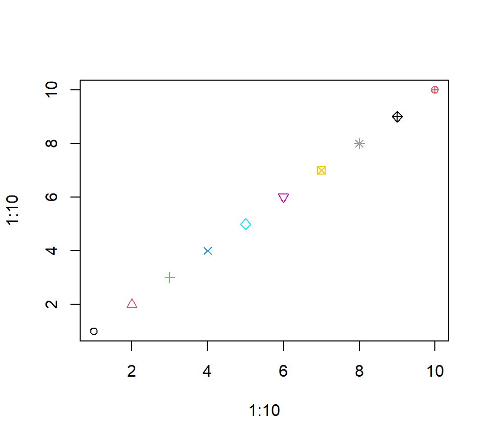

## Para mais detalhes

- https://rmarkdown.rstudio.com/ioslides_presentation_format.html
- Ou me procure: thaispaiva@est.ufmg.br.